# Credit Default Risk with Logistic Regression

Although many machine learning techniques deliver strong predictive performance, logistic regression remains the preferred choice in finance and risk management for its computational efficiency and interpretability.

In this project, I conduct data analysis, data cleaning and preparation, then build a logistic regression model to predict transaction defaults. Finally, I develop a credit scorecard from the model results.

The project employs industry-standard techniques like Weight of Evidence (WoE) for variable binning and the Youden Index (J statistic) for optimal threshold selection.

## Preprocessing

```python
# Import the required libraries
import pandas as pd
import numpy as np
import seaborn as sns
import matplotlib.pyplot as plt
from sklearn.model_selection import train_test_split, RepeatedStratifiedKFold, cross_val_score
from sklearn.linear_model import LogisticRegression
from sklearn.metrics import roc_curve, roc_auc_score, confusion_matrix, precision_recall_curve, auc
from sklearn.feature_selection import f_classif
from sklearn.pipeline import Pipeline
from sklearn.base import BaseEstimator, TransformerMixin
from scipy.stats import chi2_contingency
```

```python
#Read the data
loan_data = pd.read_csv('/Users/camnguyen/Documents/Credit_Scorecard/loan_data_2007_2014.csv')
loan_data.head()
```

|  | Unnamed: 0 | id | member_id | loan_amnt | funded_amnt | funded_amnt_inv | term | int_rate | installment | grade | ... | total_bal_il | il_util | open_rv_12m | open_rv_24m | max_bal_bc | all_util | total_rev_hi_lim | inq_fi | total_cu_tl | inq_last_12m |
| --- | --- | --- | --- | --- | --- | --- | --- | --- | --- | --- | --- | --- | --- | --- | --- | --- | --- | --- | --- | --- | --- |
| 0 | 0 | 1077501 | 1296599 | 5000 | 5000 | 4975.0 | 36 months | 10.65 | 162.87 | B | ... | NaN | NaN | NaN | NaN | NaN | NaN | NaN | NaN | NaN | NaN |
| 1 | 1 | 1077430 | 1314167 | 2500 | 2500 | 2500.0 | 60 months | 15.27 | 59.83 | C | ... | NaN | NaN | NaN | NaN | NaN | NaN | NaN | NaN | NaN | NaN |
| 2 | 2 | 1077175 | 1313524 | 2400 | 2400 | 2400.0 | 36 months | 15.96 | 84.33 | C | ... | NaN | NaN | NaN | NaN | NaN | NaN | NaN | NaN | NaN | NaN |
| 3 | 3 | 1076863 | 1277178 | 10000 | 10000 | 10000.0 | 36 months | 13.49 | 339.31 | C | ... | NaN | NaN | NaN | NaN | NaN | NaN | NaN | NaN | NaN | NaN |
| 4 | 4 | 1075358 | 1311748 | 3000 | 3000 | 3000.0 | 60 months | 12.69 | 67.79 | B | ... | NaN | NaN | NaN | NaN | NaN | NaN | NaN | NaN | NaN | NaN |

5 rows × 75 columns

```python
pd.options.display.max_columns = None
loan_data
```

|  | Unnamed: 0 | id | member_id | loan_amnt | funded_amnt | funded_amnt_inv | term | int_rate | installment | grade | sub_grade | emp_title | emp_length | home_ownership | annual_inc | verification_status | issue_d | loan_status | pymnt_plan | url | desc | purpose | title | zip_code | addr_state | dti | delinq_2yrs | earliest_cr_line | inq_last_6mths | … |
| --- | --- | --- | --- | --- | --- | --- | --- | --- | --- | --- | --- | --- | --- | --- | --- | --- | --- | --- | --- | --- | --- | --- | --- | --- | --- | --- | --- | --- | --- | --- |
| 0 | 0 | 1077501 | 1296599 | 5000 | 5000 | 4975.0 | 36 months | 10.65 | 162.87 | B | B2 | NaN | 10+ years | RENT | 24000.0 | Verified | Dec-11 | Fully Paid | n | https://www.lendingclub.com/browse/loanDetail.... | Borrower added on 12/22/11 > I need to upgra... | credit_card | Computer | 860xx | AZ | 27.65 | 0.0 | Jan-85 | 1.0 | … |
| 1 | 1 | 1077430 | 1314167 | 2500 | 2500 | 2500.0 | 60 months | 15.27 | 59.83 | C | C4 | Ryder | < 1 year | RENT | 30000.0 | Source Verified | Dec-11 | Charged Off | n | https://www.lendingclub.com/browse/loanDetail.... | Borrower added on 12/22/11 > I plan to use t... | car | bike | 309xx | GA | 1.00 | 0.0 | Apr-99 | 5.0 | … |
| 2 | 2 | 1077175 | 1313524 | 2400 | 2400 | 2400.0 | 36 months | 15.96 | 84.33 | C | C5 | NaN | 10+ years | RENT | 12252.0 | Not Verified | Dec-11 | Fully Paid | n | https://www.lendingclub.com/browse/loanDetail.... | NaN | small_business | real estate business | 606xx | IL | 8.72 | 0.0 | Nov-01 | 2.0 | … |
| 3 | 3 | 1076863 | 1277178 | 10000 | 10000 | 10000.0 | 36 months | 13.49 | 339.31 | C | C1 | AIR RESOURCES BOARD | 10+ years | RENT | 49200.0 | Source Verified | Dec-11 | Fully Paid | n | https://www.lendingclub.com/browse/loanDetail.... | Borrower added on 12/21/11 > to pay for prop... | other | personel | 917xx | CA | 20.00 | 0.0 | Feb-96 | 1.0 | … |
| 4 | 4 | 1075358 | 1311748 | 3000 | 3000 | 3000.0 | 60 months | 12.69 | 67.79 | B | B5 | University Medical Group | 1 year | RENT | 80000.0 | Source Verified | Dec-11 | Current | n | https://www.lendingclub.com/browse/loanDetail.... | Borrower added on 12/21/11 > I plan on combi... | other | Personal | 972xx | OR | 17.94 | 0.0 | Jan-96 | 0.0 | … |
| ... | ... | ... | ... | ... | ... | ... | ... | ... | ... | ... | ... | ... | ... | ... | ... | ... | ... | ... | ... | ... | ... | ... | ... | ... | ... | ... | ... | ... | ... | … |
| 466280 | 466280 | 8598660 | 1440975 | 18400 | 18400 | 18400.0 | 60 months | 14.47 | 432.64 | C | C2 | Financial Advisor | 4 years | MORTGAGE | 110000.0 | Source Verified | Jan-14 | Current | n | https://www.lendingclub.com/browse/loanDetail.... | NaN | debt_consolidation | Debt consolidation | 773xx | TX | 19.85 | 0.0 | Apr-03 | 2.0 | … |
| 466281 | 466281 | 9684700 | 11536848 | 22000 | 22000 | 22000.0 | 60 months | 19.97 | 582.50 | D | D5 | Chief of Interpretation (Park Ranger) | 10+ years | MORTGAGE | 78000.0 | Verified | Jan-14 | Charged Off | n | https://www.lendingclub.com/browse/loanDetail.... | NaN | debt_consolidation | Debt consolidation | 377xx | TN | 18.45 | 0.0 | Jun-97 | 5.0 | … |
| 466282 | 466282 | 9584776 | 11436914 | 20700 | 20700 | 20700.0 | 60 months | 16.99 | 514.34 | D | D1 | patrol | 7 years | MORTGAGE | 46000.0 | Verified | Jan-14 | Current | n | https://www.lendingclub.com/browse/loanDetail.... | Borrower added on 12/06/13 > I am going to c... | debt_consolidation | Debt consolidation | 458xx | OH | 25.65 | 0.0 | Dec-01 | 2.0 | … |
| 466283 | 466283 | 9604874 | 11457002 | 2000 | 2000 | 2000.0 | 36 months | 7.90 | 62.59 | A | A4 | Server Engineer Lead | 3 years | OWN | 83000.0 | Verified | Jan-14 | Fully Paid | n | https://www.lendingclub.com/browse/loanDetail.... | NaN | credit_card | Credit card refinancing | 913xx | CA | 5.39 | 3.0 | Feb-03 | 1.0 | … |
| 466284 | 466284 | 9199665 | 11061576 | 10000 | 10000 | 9975.0 | 36 months | 19.20 | 367.58 | D | D3 | NaN | 10+ years | MORTGAGE | 46000.0 | Verified | Jan-14 | Current | n | https://www.lendingclub.com/browse/loanDetail.... | Borrower added on 12/04/13 > I will like a l... | other | Other | 950xx | CA | 22.78 | 1.0 | Feb-00 | 0.0 | … |

466285 rows × 75 columns

| LoanStatNew | Description |
| --- | --- |
| addr_state | The state provided by the borrower in the loan application |
| annual_inc | The self-reported annual income provided by the borrower during registration. |
| annual_inc_joint | The combined self-reported annual income provided by the co-borrowers during registration |
| application_type | Indicates whether the loan is an individual application or a joint application with two co-borrowers |
| collection_recovery_fee | Post charge off collection fee |
| collections_12_mths_ex_med | Number of collections in 12 months excluding medical collections |
| delinq_2yrs | The number of 30+ days past-due incidences of delinquency in the borrower's credit file for the past 2 years |
| desc | Loan description provided by the borrower |
| dti | A ratio calculated using the borrower’s total monthly debt payments on the total debt obligations, excluding mortgage and the requested LC loan, divided by the borrower’s self-reported monthly income. |
| dti_joint | A ratio calculated using the co-borrowers' total monthly payments on the total debt obligations, excluding mortgages and the requested LC loan, divided by the co-borrowers' combined self-reported mont… |
| earliest_cr_line | The month the borrower's earliest reported credit line was opened |
| emp_length | Employment length in years. Possible values are between 0 and 10 where 0 means less than one year and 10 means ten or more years. |
| emp_title | The job title supplied by the borrower when applying for the loan. |
| fico_range_high | The upper boundary range the borrower’s FICO at loan origination belongs to. |
| fico_range_low | The lower boundary range the borrower’s FICO at loan origination belongs to. |
| funded_amnt | The total amount committed to that loan at that point in time. |
| funded_amnt_inv | The total amount committed by investors for that loan at that point in time. |
| grade | LC assigned loan grade |
| home_ownership | The home ownership status provided by the borrower during registration. Values: RENT, OWN, MORTGAGE, OTHER. |
| id | A unique LC assigned ID for the loan listing. |
| initial_list_status | The initial listing status of the loan. Possible values are – W, F |
| inq_last_6mths | The number of inquiries in past 6 months (excluding auto and mortgage inquiries) |
| installment | The monthly payment owed by the borrower if the loan originates. |
| int_rate | Interest rate on the loan |
| is_inc_v | Indicates if income was verified by LC, not verified, or if the income source was verified |
| issue_d | The month which the loan was funded |
| last_credit_pull_d | The most recent month LC pulled credit for this loan |
| last_fico_range_high | The upper boundary range the borrower’s last FICO pulled belongs to. |
| last_fico_range_low | The lower boundary range the borrower’s last FICO pulled belongs to. |
| last_pymnt_amnt | Last total payment amount received |
| last_pymnt_d | Last month payment was received |
| loan_amnt | The listed amount of the loan applied for by the borrower. If at some point in time, the credit department reduces the loan amount, then it will be reflected in this value. |
| loan_status | Current status of the loan |
| member_id | A unique LC assigned Id for the borrower member. |
| mths_since_last_delinq | The number of months since the borrower's last delinquency. |
| mths_since_last_major_derog | Months since most recent 90-day or worse rating |
| mths_since_last_record | The number of months since the last public record. |
| next_pymnt_d | Next scheduled payment date |
| open_acc | The number of open credit lines in the borrower's credit file. |
| out_prncp | Remaining outstanding principal for total amount funded |
| out_prncp_inv | Remaining outstanding principal for portion of total amount funded by investors |
| policy_code | Publicly available policy_code=1; new products not publicly available policy_code=2 |
| pub_rec | Number of derogatory public records |
| purpose | A category provided by the borrower for the loan request. |
| pymnt_plan | Indicates if a payment plan has been put in place for the loan |
| recoveries | Post charge off gross recovery |
| revol_bal | Total credit revolving balance |
| revol_util | Revolving line utilization rate, or the amount of credit the borrower is using relative to all available revolving credit. |
| sub_grade | LC assigned loan subgrade |
| term | The number of payments on the loan. Values are in months and can be either 36 or 60. |
| title | The loan title provided by the borrower |
| total_acc | The total number of credit lines currently in the borrower's credit file |
| total_pymnt | Payments received to date for total amount funded |
| total_pymnt_inv | Payments received to date for portion of total amount funded by investors |
| total_rec_int | Interest received to date |
| total_rec_late_fee | Late fees received to date |
| total_rec_prncp | Principal received to date |
| url | URL for the LC page with listing data. |
| verified_status_joint | Indicates if the co-borrowers' joint income was verified by LC, not verified, or if the income source was verified |
| zip_code | The first 3 numbers of the zip code provided by the borrower in the loan application. |
| open_acc_6m | Number of open trades in last 6 months |
| open_il_6m | Number of currently active installment trades |
| open_il_12m | Number of installment accounts opened in past 12 months |
| open_il_24m | Number of installment accounts opened in past 24 months |
| mths_since_rcnt_il | Months since most recent installment accounts opened |
| total_bal_il | Total current balance of all installment accounts |
| il_util | Ratio of total current balance to high credit/credit limit on all install accounts |
| open_rv_12m | Number of revolving trades opened in past 12 months |
| open_rv_24m | Number of revolving trades opened in past 24 months |
| max_bal_bc | Maximum current balance owed on all revolving accounts |
| all_util | Balance to credit limit on all trades |
| total_rev_hi_lim | Total revolving high credit/credit limit |
| inq_fi | Number of personal finance inquiries |
| total_cu_tl | Number of finance trades |
| inq_last_12m | Number of credit inquiries in past 12 months |
| acc_now_delinq | The number of accounts on which the borrower is now delinquent. |
| tot_coll_amt | Total collection amounts ever owed |
| tot_cur_bal | Total current balance of all accounts |

Variables we will need for further analysis: annual_inc, deling_2yrs, inq_last_6mths, open_acc, pub_rec, total_acc, acc_now_deling, total_rev_hi_lim, emp_length_int, mths_since_earliest_cr_line

```python
#please show all column in the dataframe
pd.set_option('display.max_columns', None)
```

```python
loan_data.info()
```

```
<class 'pandas.DataFrame'>
RangeIndex: 466285 entries, 0 to 466284
Data columns (total 75 columns):
 #   Column                       Non-Null Count   Dtype
---  ------                       --------------   -----
 0   Unnamed: 0                   466285 non-null  int64
 1   id                           466285 non-null  int64
 2   member_id                    466285 non-null  int64
 3   loan_amnt                    466285 non-null  int64
 4   funded_amnt                  466285 non-null  int64
 5   funded_amnt_inv              466285 non-null  float64
 6   term                         466285 non-null  str
 7   int_rate                     466285 non-null  float64
 8   installment                  466285 non-null  float64
 9   grade                        466285 non-null  str
```

[output cut: 67 more lines]

```python
pip install openpyxl
```

[output not shown]

```python
#show all the fully paid column values
loan_data['loan_status'].value_counts()
```

```
loan_status
Current                                                224226
Fully Paid                                             184739
Charged Off                                             42475
Late (31-120 days)                                       6900
In Grace Period                                          3146
Does not meet the credit policy. Status:Fully Paid       1988
Late (16-30 days)                                        1218
Default                                                   832
Does not meet the credit policy. Status:Charged Off       761
Name: count, dtype: int64
```

```python
loan_data['annual_inc'].fillna(loan_data['annual_inc'].mean(), inplace=True)
# We fill the missing values with the mean value of the non-missing values.
```

[output not shown]

```
0          24000.0
1          30000.0
2          12252.0
3          49200.0
4          80000.0
            ...
466280    110000.0
466281     78000.0
466282     46000.0
466283     83000.0
466284     46000.0
Name: annual_inc, Length: 466285, dtype: float64
```

```python
# get a list of columns that have more than 80% null values
na_values = loan_data.isnull().mean()
na_values[na_values>0.8]
```

```
mths_since_last_record       0.865666
annual_inc_joint             1.000000
dti_joint                    1.000000
verification_status_joint    1.000000
open_acc_6m                  1.000000
open_il_6m                   1.000000
open_il_12m                  1.000000
open_il_24m                  1.000000
mths_since_rcnt_il           1.000000
total_bal_il                 1.000000
il_util                      1.000000
open_rv_12m                  1.000000
open_rv_24m                  1.000000
max_bal_bc                   1.000000
all_util                     1.000000
inq_fi                       1.000000
total_cu_tl                  1.000000
inq_last_12m                 1.000000
dtype: float64
```

```python
# drop columns with more than 80% null values
loan_data.dropna(thresh = loan_data.shape[0]*0.2,  axis = 1, inplace = True)

'''
drop redundant and forward-looking columns
redundant like id, member_id, title, etc.
forward-looking like recoveries, collection_recovery_fee, etc.
drop sub_grade as same information is captured in grade column
drop next_pymnt_d since, given that our data is historical and this column is supposed to have future dates, will not make sense for our model
'''
loan_data.drop(columns = ['id', 'member_id', 'sub_grade', 'emp_title', 'url', 'desc', 'title', 'zip_code', 'next_pymnt_d',
                          'recoveries', 'collection_recovery_fee', 'total_rec_prncp', 'total_rec_late_fee'], inplace = True)
```

```python
loan_data.info()
```

```
<class 'pandas.DataFrame'>
RangeIndex: 466285 entries, 0 to 466284
Data columns (total 44 columns):
 #   Column                       Non-Null Count   Dtype
---  ------                       --------------   -----
 0   Unnamed: 0                   466285 non-null  int64
 1   loan_amnt                    466285 non-null  int64
 2   funded_amnt                  466285 non-null  int64
 3   funded_amnt_inv              466285 non-null  float64
 4   term                         466285 non-null  str
 5   int_rate                     466285 non-null  float64
 6   installment                  466285 non-null  float64
 7   grade                        466285 non-null  str
 8   emp_length                   445277 non-null  str
 9   home_ownership               466285 non-null  str
```

[output cut: 36 more lines]

### Preprocessing continuous variables

```python
loan_data['emp_length'].unique()
```

```
<StringArray>
['10+ years',  '< 1 year',    '1 year',   '3 years',   '8 years',   '9 years',
   '4 years',   '5 years',   '6 years',   '2 years',   '7 years',         nan]
Length: 12, dtype: str
```

emp_length now is still object

```python
#remove notify
import warnings
warnings.filterwarnings('ignore')
```

```python
loan_data['loan_status'].unique()
# Displays unique values of a column.
```

```
<StringArray>
[                                         'Fully Paid',
                                         'Charged Off',
                                             'Current',
                                             'Default',
                                  'Late (31-120 days)',
                                     'In Grace Period',
                                   'Late (16-30 days)',
  'Does not meet the credit policy. Status:Fully Paid',
 'Does not meet the credit policy. Status:Charged Off']
Length: 9, dtype: str
```

```python
# create a new column based on the loan_status column that will be our target variable
loan_data['good_bad'] = np.where(loan_data.loc[:, 'loan_status'].isin(['Charged Off', 'Default', 'Late (31-120 days)',
                                                                       'Does not meet the credit policy. Status:Charged Off']), 0, 1)
# Drop the original 'loan_status' column
loan_data.drop(columns = ['loan_status'], inplace = True)
```

## Exploratory Data Analysis

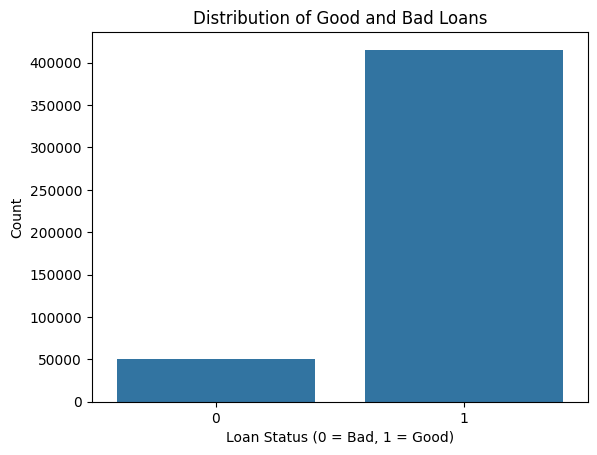

```python
#number of good and bad loans
loan_data['good_bad'].value_counts()
#plot the distribution of the target variable
sns.countplot(x = 'good_bad', data = loan_data)
plt.title('Distribution of Good and Bad Loans')
plt.xlabel('Loan Status (0 = Bad, 1 = Good)')
plt.ylabel('Count')
plt.show()
```

The distribution is completely imbalanced

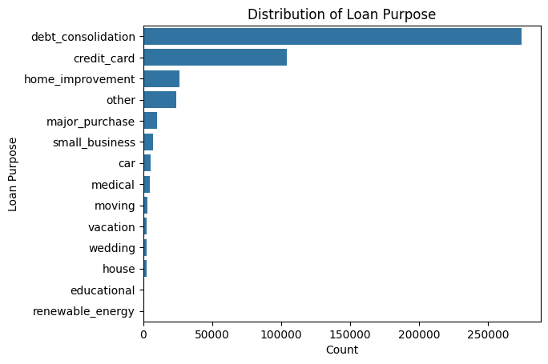

```python
# show the number of loan through purpose
loan_data['purpose'].value_counts()
# plot the distribution of loan purpose as a horizontal bar chart
sns.countplot(y = 'purpose', data = loan_data, order = loan_data['purpose'].value_counts().index)
plt.title('Distribution of Loan Purpose')
plt.xlabel('Count')
plt.ylabel('Loan Purpose')
plt.show()
```

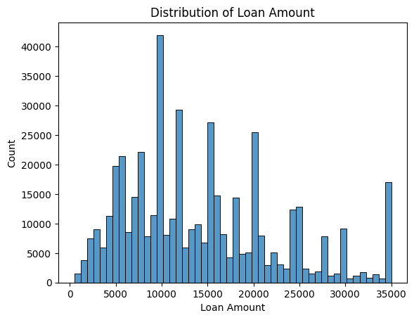

```python
#plot the highest loan amount
sns.histplot(x = 'loan_amnt', data = loan_data, bins = 50)
plt.title('Distribution of Loan Amount')
plt.xlabel('Loan Amount')
plt.ylabel('Count')
plt.show()
```

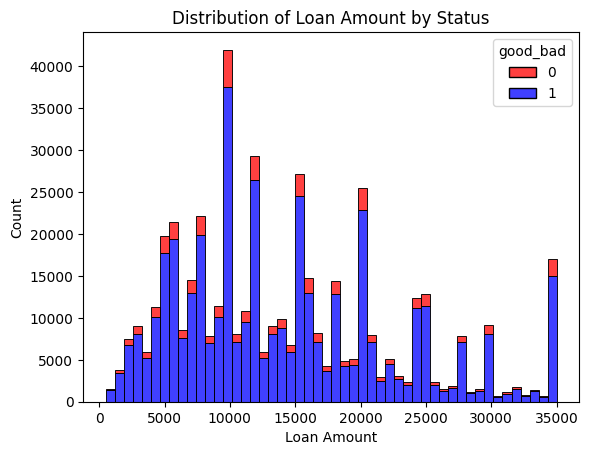

```python
import seaborn as sns
import matplotlib.pyplot as plt

# Using hue to differentiate groups and palette to assign specific colors
# 1 (Good) = Blue, 0 (Bad) = Red
sns.histplot(x='loan_amnt', data=loan_data, bins=50,
             hue='good_bad', palette={1: 'blue', 0: 'red'},
             multiple="stack")  # 'stack' or 'dodge' helps make it more readable

plt.title('Distribution of Loan Amount by Status')
plt.xlabel('Loan Amount')
plt.ylabel('Count')

# Seaborn automatically generates the legend when using the 'hue' parameter
plt.show()
```

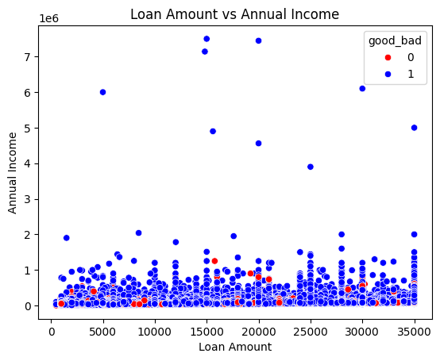

```python
#plot the highest loan amount and also make the red color for the bad loans and blue color for the good loans
sns.scatterplot(x = 'loan_amnt', y = 'annual_inc', hue = 'good_bad', data = loan_data, palette = {0: 'red', 1: 'blue'})
plt.title('Loan Amount vs Annual Income')
plt.xlabel('Loan Amount')
plt.ylabel('Annual Income')
plt.show()
```

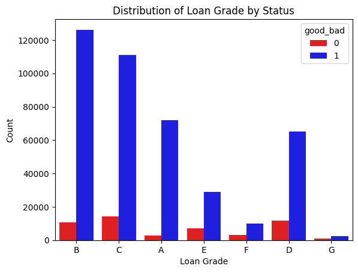

```python
#plot the relation ship betwwen grade and number of good and bad loans
sns.countplot(x = 'grade', hue = 'good_bad', data = loan_data, palette = {0: 'red', 1: 'blue'})
plt.title('Distribution of Loan Grade by Status')
plt.xlabel('Loan Grade')
plt.ylabel('Count')
plt.show()
```

## Split the data

```python
# split data into 80/20 while keeping the distribution of bad loans in test set same as that in the pre-split dataset
X = loan_data.drop('good_bad', axis = 1)
y = loan_data['good_bad']
X_train, X_test, y_train, y_test = train_test_split(X, y, test_size = 0.2, random_state = 42, stratify = y)

# specifically hard copying the training sets to avoid Pandas' SetttingWithCopyWarning when we play around with this data later on.
# as noted [here](https://github.com/scikit-learn/scikit-learn/issues/8723), this is currently an open issue between Pandas and Scikit-Learn teams
X_train, X_test = X_train.copy(), X_test.copy()
```

## General Data Cleaning

```python
loan_data['issue_d']
```

```
0         Dec-11
1         Dec-11
2         Dec-11
3         Dec-11
4         Dec-11
           ...
466280    Jan-14
466281    Jan-14
466282    Jan-14
466283    Jan-14
466284    Jan-14
Name: issue_d, Length: 466285, dtype: str
```

```python
import pandas as pd
import numpy as np
# function to convert date columns to month difference from a reference date (e.g. today)
def date_columns(df, column):
    today_date = pd.to_datetime('2017-12-01')
    # z.B. "Dec-15" -> 2015-12-01
    df[column] = pd.to_datetime(df[column], format="%b-%y", errors="coerce")

    # exact month difference: year * 12 + month
    m_col = 'mths_since_' + column
    df[m_col] = (
        (today_date.year - df[column].dt.year) * 12
        + (today_date.month - df[column].dt.month)
    )

    # replace negatives with max (ignoring NaNs)
    max_val = df[m_col].max()
    df[m_col] = df[m_col].apply(lambda x: max_val if pd.notna(x) and x < 0 else x)

    df.drop(columns=[column], inplace=True)
```

```python
# apply the function to the relevant date columns
date_columns(X_train, 'earliest_cr_line')
date_columns(X_train, 'issue_d')
date_columns(X_train, 'last_pymnt_d')
date_columns(X_train, 'last_credit_pull_d')
```

```python
# check the new columns
print(X_train['mths_since_earliest_cr_line'].describe())
print(X_train['mths_since_issue_d'].describe())
print(X_train['mths_since_last_pymnt_d'].describe())
print(X_train['mths_since_last_credit_pull_d'].describe())
```

```
count    373003.000000
mean        242.293609
std          86.372742
min          73.000000
25%         183.000000
50%         225.000000
75%         285.000000
max         587.000000
Name: mths_since_earliest_cr_line, dtype: float64
count    373028.000000
mean         51.252485
std          14.339074
min          36.000000
25%          41.000000
50%          47.000000
75%          57.000000
max         126.000000
Name: mths_since_issue_d, dtype: float64
count    372717.000000
mean         31.289989
std          12.803859
min          23.000000
25%          23.000000
50%          24.000000
75%          35.000000
max         120.000000
Name: mths_since_last_pymnt_d, dtype: float64
count    372998.000000
mean         27.041810
std           9.630887
min          23.000000
25%          23.000000
50%          23.000000
75%          25.000000
max         127.000000
Name: mths_since_last_credit_pull_d, dtype: float64
```

```python
loan_data['term']
```

```
0          36 months
1          60 months
2          36 months
3          36 months
4          60 months
             ...
466280     60 months
466281     60 months
466282     60 months
466283     36 months
466284     36 months
Name: term, Length: 466285, dtype: str
```

```python
# function to remove 'months' string from the 'term' column and convert it to numeric
def loan_term_converter(df, column):
    df[column] = pd.to_numeric(df[column].str.replace(' months', ''))

loan_term_converter(X_train, 'term')
```

```python
X_train["term"].unique()
```

```
array([36, 60])
```

```python
# first divide training data into categorical and numerical subsets
X_train_cat = X_train.select_dtypes(include = 'object').copy()
X_train_num = X_train.select_dtypes(include = 'number').copy()
```

```python
# define an empty dictionary to store chi-squared test results
chi2_check = {}

# loop over each column in the training set to calculate chi-statistic with the target variable
for column in X_train_cat:
    chi, p, dof, ex = chi2_contingency(pd.crosstab(y_train, X_train_cat[column]))
    chi2_check.setdefault('Feature',[]).append(column)
    chi2_check.setdefault('p-value',[]).append(round(p, 10))

# convert the dictionary to a DF
chi2_result = pd.DataFrame(data = chi2_check)
chi2_result.sort_values(by = ['p-value'], ascending = True, ignore_index = True, inplace = True)
chi2_result
```

|  | Feature | p-value |
| --- | --- | --- |
| 0 | grade | 0.000000 |
| 1 | emp_length | 0.000000 |
| 2 | home_ownership | 0.000000 |
| 3 | verification_status | 0.000000 |
| 4 | purpose | 0.000000 |
| 5 | addr_state | 0.000000 |
| 6 | initial_list_status | 0.000000 |
| 7 | pymnt_plan | 0.000923 |
| 8 | application_type | 1.000000 |

- The Chi-Squared test of independence is used here to see if a categorical feature and the target variable are independent or related.
- Low P-Value (typically < 0.05): This suggests a strong relationship. We should keep this features
- High P-Value (close to 1.0): This suggests the feature is "independent" of the target.

```python
# since f_class_if does not accept missing values, we will do a very crude imputation of missing values
X_train_num.fillna(X_train_num.mean(), inplace = True)
# Calculate F Statistic and corresponding p values
F_statistic, p_values = f_classif(X_train_num, y_train)
# convert to a DF
# anova f test is used to check if there is a significant difference in the means of the numerical features between the two classes of the target variable (good vs bad loans). A high F-score and a low p-value indicate that the feature is likely to be a good predictor of the target variable.
ANOVA_F_table = pd.DataFrame(data = {'Numerical_Feature': X_train_num.columns.values, 'F-Score': F_statistic, 'p values': p_values.round(decimals=10)})
ANOVA_F_table.sort_values(by = ['F-Score'], ascending = False, ignore_index = True, inplace = True)
ANOVA_F_table
```

|  | Numerical_Feature | F-Score | p values |
| --- | --- | --- | --- |
| 0 | mths_since_last_pymnt_d | 23513.805570 | 0.000000e+00 |
| 1 | total_pymnt_inv | 14784.534040 | 0.000000e+00 |
| 2 | total_pymnt | 14686.729567 | 0.000000e+00 |
| 3 | int_rate | 11462.788313 | 0.000000e+00 |
| 4 | last_pymnt_amnt | 10826.949727 | 0.000000e+00 |
| 5 | out_prncp | 9635.116160 | 0.000000e+00 |
| 6 | out_prncp_inv | 9633.442129 | 0.000000e+00 |
| 7 | mths_since_last_credit_pull_d | 7020.218888 | 0.000000e+00 |
| 8 | mths_since_issue_d | 2816.028871 | 0.000000e+00 |
| 9 | inq_last_6mths | 2003.820465 | 0.000000e+00 |
| 10 | term | 1590.811890 | 0.000000e+00 |
| 11 | Unnamed: 0 | 1143.897928 | 0.000000e+00 |
| 12 | revol_util | 931.880533 | 0.000000e+00 |
| 13 | dti | 863.811228 | 0.000000e+00 |
| 14 | annual_inc | 861.298449 | 0.000000e+00 |
| 15 | tot_cur_bal | 784.596617 | 0.000000e+00 |
| 16 | mths_since_earliest_cr_line | 447.541677 | 0.000000e+00 |
| 17 | total_rev_hi_lim | 377.070243 | 0.000000e+00 |
| 18 | total_rec_int | 273.765687 | 0.000000e+00 |
| 19 | total_acc | 208.751175 | 0.000000e+00 |
| 20 | revol_bal | 119.561249 | 0.000000e+00 |
| 21 | installment | 74.947851 | 0.000000e+00 |
| 22 | loan_amnt | 57.496753 | 0.000000e+00 |
| 23 | funded_amnt | 50.089615 | 0.000000e+00 |
| 24 | pub_rec | 39.596857 | 3.000000e-10 |
| 25 | funded_amnt_inv | 23.260798 | 1.415100e-06 |
| 26 | open_acc | 16.299684 | 5.408370e-05 |
| 27 | collections_12_mths_ex_med | 7.358687 | 6.674257e-03 |
| 28 | mths_since_last_major_derog | 3.116419 | 7.750777e-02 |
| 29 | mths_since_last_delinq | 3.079668 | 7.927751e-02 |
| 30 | delinq_2yrs | 1.066138 | 3.018201e-01 |
| 31 | acc_now_delinq | 0.690407 | 4.060264e-01 |
| 32 | tot_coll_amt | 0.393157 | 5.306448e-01 |
| 33 | policy_code | NaN | NaN |

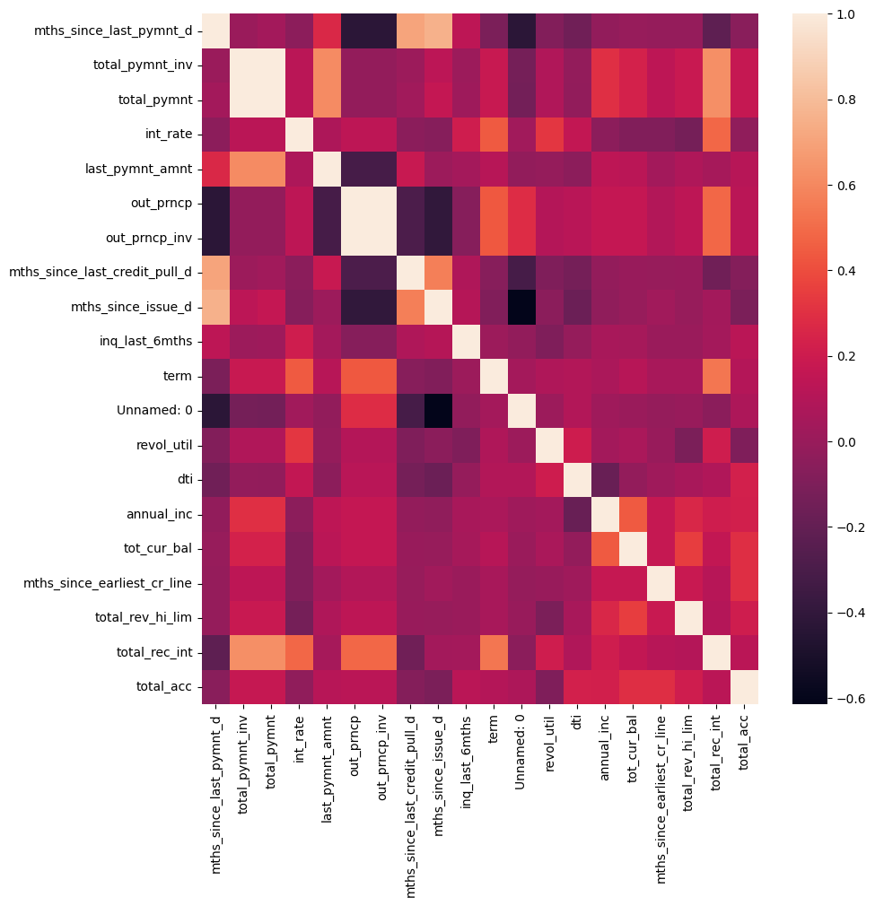

```python
# save the top 20 numerical features in a list
top_num_features = ANOVA_F_table.iloc[:20,0].to_list()
# calculate pair-wise correlations between them
corrmat = X_train_num[top_num_features].corr()
plt.figure(figsize=(10,10))
sns.heatmap(corrmat);
```

## Dummy Variables

Convert discrete variables to dummy variables

```python
X_train.info()
```

```
<class 'pandas.DataFrame'>
Index: 373028 entries, 456615 to 38736
Data columns (total 43 columns):
 #   Column                         Non-Null Count   Dtype
---  ------                         --------------   -----
 0   Unnamed: 0                     373028 non-null  int64
 1   loan_amnt                      373028 non-null  int64
 2   funded_amnt                    373028 non-null  int64
 3   funded_amnt_inv                373028 non-null  float64
 4   term                           373028 non-null  int64
 5   int_rate                       373028 non-null  float64
 6   installment                    373028 non-null  float64
 7   grade                          373028 non-null  str
 8   emp_length                     356235 non-null  str
 9   home_ownership                 373028 non-null  str
```

[output cut: 35 more lines]

```python
import pandas as pd
# function to convert employment length to numeric
def emp_length_converter(df, column):
    if column not in df.columns:
        return  # nothing to do

    s = df[column].fillna("0 years")

    df[column + "_int"] = (
        s.str.replace(r"\+ years", "", regex=True)   # "10+ years" -> "10"
         .str.replace("years", "", regex=False)
         .str.replace("year", "", regex=False)
         .str.replace("< 1", "0", regex=False)       # "< 1 year" -> "0"
         .str.replace("n/a", "0", regex=False)
         .str.strip()
    )

    df[column + "_int"] = (
        pd.to_numeric(df[column + "_int"], errors="coerce")
          .astype("Int64")
    )
    df["emp_length"] = df["emp_length_int"]
# Anwendung
emp_length_converter(X_train, "emp_length")
```

```python
# function to create dummy variables
def dummy_creation(df, columns_list):
    # create an empty list to store the dummy variable dataframes
    df_dummies = []
    # loop through the list of columns and create dummy variables for each column, then concatenate them together
    for col in columns_list:
        #get_dummies() is a function in pandas that converts categorical variables into dummy/indicator variables. The prefix and prefix_sep arguments are used to create more informative column names for the dummy variables, e.g. "grade_A", "grade_B", etc. instead of just "A", "B", etc.
        df_dummies.append(pd.get_dummies(df[col], prefix = col, prefix_sep = ':'))
    # concatenate the dummy variables together axis = 1 means we want to concatenate horizontally (i.e. add more columns)
    df_dummies = pd.concat(df_dummies, axis = 1)
    # concatenate the dummy variables with the original dataframe
    df = pd.concat([df, df_dummies], axis = 1)
    return df

# apply to our final four categorical variables
X_train = dummy_creation(X_train, ['grade', 'home_ownership', 'verification_status', 'purpose'])
```

```python
X_train
```

|  | Unnamed: 0 | loan_amnt | funded_amnt | funded_amnt_inv | term | int_rate | installment | grade | emp_length | home_ownership | annual_inc | verification_status | pymnt_plan | purpose | addr_state | dti | delinq_2yrs | inq_last_6mths | mths_since_last_delinq | open_acc | pub_rec | revol_bal | revol_util | total_acc | initial_list_status | out_prncp | out_prncp_inv | total_pymnt | total_pymnt_inv | … |
| --- | --- | --- | --- | --- | --- | --- | --- | --- | --- | --- | --- | --- | --- | --- | --- | --- | --- | --- | --- | --- | --- | --- | --- | --- | --- | --- | --- | --- | --- | --- |
| 456615 | 456615 | 15000 | 15000 | 15000.0 | 36 | 8.90 | 476.30 | A | 7 | MORTGAGE | 80000.0 | Source Verified | n | credit_card | WI | 17.01 | 1.0 | 0.0 | 20.0 | 19.0 | 0.0 | 20699 | 59.0 | 32.0 | w | 0.00 | 0.00 | 16561.02000 | 16561.02 | … |
| 451541 | 451541 | 8000 | 8000 | 8000.0 | 60 | 18.25 | 204.24 | D | 10 | OWN | 44000.0 | Verified | n | other | TN | 23.46 | 0.0 | 1.0 | NaN | 12.0 | 0.0 | 13245 | 32.1 | 25.0 | f | 5746.54 | 5746.54 | 4697.52000 | 4697.52 | … |
| 394474 | 394474 | 12150 | 12150 | 12100.0 | 60 | 18.92 | 314.65 | D | 3 | OWN | 27000.0 | Source Verified | n | credit_card | TN | 31.07 | 1.0 | 0.0 | 10.0 | 9.0 | 0.0 | 7172 | 73.2 | 22.0 | f | 9282.24 | 9244.04 | 6293.00000 | 6267.10 | … |
| 110294 | 110294 | 10000 | 10000 | 10000.0 | 36 | 6.03 | 304.36 | A | 3 | MORTGAGE | 33000.0 | Not Verified | n | debt_consolidation | TN | 9.16 | 0.0 | 0.0 | NaN | 5.0 | 0.0 | 2138 | 21.2 | 17.0 | w | 0.00 | 0.00 | 10858.01000 | 10858.01 | … |
| 139343 | 139343 | 15825 | 15825 | 15825.0 | 36 | 12.12 | 526.53 | B | 10 | MORTGAGE | 59000.0 | Verified | n | debt_consolidation | WA | 17.94 | 0.0 | 0.0 | NaN | 7.0 | 0.0 | 30326 | 93.6 | 31.0 | f | 0.00 | 0.00 | 4736.52000 | 4736.52 | … |
| ... | ... | ... | ... | ... | ... | ... | ... | ... | ... | ... | ... | ... | ... | ... | ... | ... | ... | ... | ... | ... | ... | ... | ... | ... | ... | ... | ... | ... | ... | … |
| 163633 | 163633 | 22800 | 22800 | 22800.0 | 60 | 16.29 | 557.98 | C | 10 | MORTGAGE | 85000.0 | Verified | n | debt_consolidation | CA | 15.12 | 0.0 | 0.0 | 38.0 | 15.0 | 0.0 | 18556 | 67.5 | 22.0 | f | 12158.37 | 12158.37 | 18968.20000 | 18968.20 | … |
| 399306 | 399306 | 20275 | 20275 | 20175.0 | 36 | 12.49 | 678.18 | B | 7 | MORTGAGE | 48000.0 | Verified | n | credit_card | KS | 22.70 | 0.0 | 0.0 | NaN | 7.0 | 0.0 | 33997 | 75.0 | 20.0 | w | 9947.82 | 9898.75 | 13563.60000 | 13496.70 | … |
| 57787 | 57787 | 25000 | 25000 | 24975.0 | 60 | 14.30 | 585.61 | C | 0 | MORTGAGE | 65530.0 | Verified | n | debt_consolidation | CO | 22.91 | 0.0 | 0.0 | NaN | 8.0 | 0.0 | 11848 | 68.1 | 24.0 | f | 0.00 | 0.00 | 30285.29598 | 30255.01 | … |
| 81641 | 81641 | 10000 | 10000 | 10000.0 | 36 | 15.10 | 347.15 | C | 4 | MORTGAGE | 50000.0 | Not Verified | n | debt_consolidation | FL | 14.24 | 1.0 | 1.0 | 10.0 | 7.0 | 0.0 | 9693 | 65.1 | 9.0 | w | 2936.24 | 2936.24 | 9373.05000 | 9373.05 | … |
| 38736 | 38736 | 7500 | 7500 | 0.0 | 36 | 10.08 | 242.29 | B | 7 | MORTGAGE | 50000.0 | Not Verified | n | debt_consolidation | CA | 2.93 | 0.0 | 3.0 | NaN | 5.0 | 0.0 | 8453 | 77.6 | 17.0 | f | 0.00 | 0.00 | 4848.62000 | 0.00 | … |

373028 rows × 73 columns

Update the test data set with all data cleaning procedures performed so far

```python
X_test
```

|  | Unnamed: 0 | loan_amnt | funded_amnt | funded_amnt_inv | term | int_rate | installment | grade | emp_length | home_ownership | annual_inc | verification_status | issue_d | pymnt_plan | purpose | addr_state | dti | delinq_2yrs | earliest_cr_line | inq_last_6mths | mths_since_last_delinq | open_acc | pub_rec | revol_bal | revol_util | total_acc | initial_list_status | out_prncp | out_prncp_inv | … |
| --- | --- | --- | --- | --- | --- | --- | --- | --- | --- | --- | --- | --- | --- | --- | --- | --- | --- | --- | --- | --- | --- | --- | --- | --- | --- | --- | --- | --- | --- | --- |
| 395346 | 395346 | 1800 | 1800 | 1800.0 | 36 months | 14.64 | 62.09 | C | 10+ years | OWN | 50000.0 | Source Verified | May-14 | n | home_improvement | FL | 19.11 | 0.0 | Sep-91 | 4.0 | NaN | 7.0 | 1.0 | 1203 | 49.0 | 32.0 | w | 0.00 | 0.00 | … |
| 376583 | 376583 | 6000 | 6000 | 6000.0 | 36 months | 7.12 | 185.60 | A | 1 year | RENT | 63000.0 | Not Verified | Jun-14 | n | debt_consolidation | GA | 7.98 | 0.0 | Jul-98 | 0.0 | NaN | 9.0 | 0.0 | 1921 | 7.1 | 24.0 | w | 2992.57 | 2992.57 | … |
| 297790 | 297790 | 10700 | 10700 | 10650.0 | 36 months | 14.99 | 370.87 | C | < 1 year | RENT | 82000.0 | Source Verified | Oct-14 | n | debt_consolidation | AZ | 23.35 | 1.0 | Aug-00 | 2.0 | 2.0 | 8.0 | 0.0 | 3174 | 58.8 | 39.0 | f | 0.00 | 0.00 | … |
| 47347 | 47347 | 15000 | 15000 | 15000.0 | 36 months | 9.67 | 481.69 | B | 2 years | RENT | 60000.0 | Verified | Dec-13 | n | debt_consolidation | FL | 28.34 | 0.0 | Feb-93 | 1.0 | NaN | 10.0 | 0.0 | 14920 | 26.1 | 17.0 | f | 0.00 | 0.00 | … |
| 446772 | 446772 | 14000 | 14000 | 13925.0 | 60 months | 18.25 | 357.42 | D | 10+ years | MORTGAGE | 86000.0 | Source Verified | Feb-14 | n | debt_consolidation | TX | 31.02 | 0.0 | Nov-90 | 0.0 | NaN | 11.0 | 0.0 | 26064 | 80.2 | 35.0 | f | 0.00 | 0.00 | … |
| ... | ... | ... | ... | ... | ... | ... | ... | ... | ... | ... | ... | ... | ... | ... | ... | ... | ... | ... | ... | ... | ... | ... | ... | ... | ... | ... | ... | ... | ... | … |
| 32147 | 32147 | 2500 | 2500 | 2500.0 | 36 months | 6.39 | 76.51 | A | 10+ years | OWN | 33600.0 | Not Verified | Feb-10 | n | medical | SC | 3.39 | 0.0 | Dec-92 | 1.0 | NaN | 15.0 | 0.0 | 3375 | 7.8 | 31.0 | f | 0.00 | 0.00 | … |
| 78936 | 78936 | 10400 | 10400 | 10400.0 | 36 months | 19.52 | 383.97 | D | 6 years | RENT | 42000.0 | Not Verified | Oct-13 | n | debt_consolidation | WA | 21.71 | 0.0 | Jan-07 | 1.0 | NaN | 16.0 | 0.0 | 12715 | 76.6 | 22.0 | f | 3190.81 | 3190.81 | … |
| 459582 | 459582 | 3000 | 3000 | 3000.0 | 36 months | 23.40 | 116.76 | E | 8 years | MORTGAGE | 30000.0 | Not Verified | Jan-14 | n | other | NY | 17.48 | 0.0 | Oct-05 | 0.0 | NaN | 7.0 | 0.0 | 13181 | 94.1 | 8.0 | f | 1238.46 | 1238.46 | … |
| 454915 | 454915 | 24000 | 24000 | 24000.0 | 60 months | 15.61 | 578.68 | C | 5 years | MORTGAGE | 80000.0 | Verified | Jan-14 | n | debt_consolidation | MN | 20.60 | 0.0 | Apr-91 | 0.0 | NaN | 20.0 | 3.0 | 17121 | 62.0 | 33.0 | f | 16908.62 | 16908.62 | … |
| 223621 | 223621 | 23325 | 23325 | 23300.0 | 36 months | 13.11 | 787.15 | B | 7 years | RENT | 47000.0 | Verified | Mar-12 | n | credit_card | AZ | 21.18 | 0.0 | Jan-94 | 0.0 | NaN | 13.0 | 0.0 | 27918 | 71.0 | 27.0 | f | 0.00 | 0.00 | … |

93257 rows × 43 columns

```python
print(X_test.columns.tolist())
'earliest_cr_line' in X_test.columns  # should be False
```

```
['Unnamed: 0', 'loan_amnt', 'funded_amnt', 'funded_amnt_inv', 'term', 'int_rate', 'installment', 'grade', 'emp_length', 'home_ownership', 'annual_inc', 'verification_status', 'issue_d', 'pymnt_plan', 'purpose', 'addr_state', 'dti', 'delinq_2yrs', 'earliest_cr_line', 'inq_last_6mths', 'mths_since_las…
```

```
True
```

```python
X_train
```

|  | Unnamed: 0 | loan_amnt | funded_amnt | funded_amnt_inv | term | int_rate | installment | grade | emp_length | home_ownership | annual_inc | verification_status | pymnt_plan | purpose | addr_state | dti | delinq_2yrs | inq_last_6mths | mths_since_last_delinq | open_acc | pub_rec | revol_bal | revol_util | total_acc | initial_list_status | out_prncp | out_prncp_inv | total_pymnt | total_pymnt_inv | … |
| --- | --- | --- | --- | --- | --- | --- | --- | --- | --- | --- | --- | --- | --- | --- | --- | --- | --- | --- | --- | --- | --- | --- | --- | --- | --- | --- | --- | --- | --- | --- |
| 456615 | 456615 | 15000 | 15000 | 15000.0 | 36 | 8.90 | 476.30 | A | 7 | MORTGAGE | 80000.0 | Source Verified | n | credit_card | WI | 17.01 | 1.0 | 0.0 | 20.0 | 19.0 | 0.0 | 20699 | 59.0 | 32.0 | w | 0.00 | 0.00 | 16561.02000 | 16561.02 | … |
| 451541 | 451541 | 8000 | 8000 | 8000.0 | 60 | 18.25 | 204.24 | D | 10 | OWN | 44000.0 | Verified | n | other | TN | 23.46 | 0.0 | 1.0 | NaN | 12.0 | 0.0 | 13245 | 32.1 | 25.0 | f | 5746.54 | 5746.54 | 4697.52000 | 4697.52 | … |
| 394474 | 394474 | 12150 | 12150 | 12100.0 | 60 | 18.92 | 314.65 | D | 3 | OWN | 27000.0 | Source Verified | n | credit_card | TN | 31.07 | 1.0 | 0.0 | 10.0 | 9.0 | 0.0 | 7172 | 73.2 | 22.0 | f | 9282.24 | 9244.04 | 6293.00000 | 6267.10 | … |
| 110294 | 110294 | 10000 | 10000 | 10000.0 | 36 | 6.03 | 304.36 | A | 3 | MORTGAGE | 33000.0 | Not Verified | n | debt_consolidation | TN | 9.16 | 0.0 | 0.0 | NaN | 5.0 | 0.0 | 2138 | 21.2 | 17.0 | w | 0.00 | 0.00 | 10858.01000 | 10858.01 | … |
| 139343 | 139343 | 15825 | 15825 | 15825.0 | 36 | 12.12 | 526.53 | B | 10 | MORTGAGE | 59000.0 | Verified | n | debt_consolidation | WA | 17.94 | 0.0 | 0.0 | NaN | 7.0 | 0.0 | 30326 | 93.6 | 31.0 | f | 0.00 | 0.00 | 4736.52000 | 4736.52 | … |
| ... | ... | ... | ... | ... | ... | ... | ... | ... | ... | ... | ... | ... | ... | ... | ... | ... | ... | ... | ... | ... | ... | ... | ... | ... | ... | ... | ... | ... | ... | … |
| 163633 | 163633 | 22800 | 22800 | 22800.0 | 60 | 16.29 | 557.98 | C | 10 | MORTGAGE | 85000.0 | Verified | n | debt_consolidation | CA | 15.12 | 0.0 | 0.0 | 38.0 | 15.0 | 0.0 | 18556 | 67.5 | 22.0 | f | 12158.37 | 12158.37 | 18968.20000 | 18968.20 | … |
| 399306 | 399306 | 20275 | 20275 | 20175.0 | 36 | 12.49 | 678.18 | B | 7 | MORTGAGE | 48000.0 | Verified | n | credit_card | KS | 22.70 | 0.0 | 0.0 | NaN | 7.0 | 0.0 | 33997 | 75.0 | 20.0 | w | 9947.82 | 9898.75 | 13563.60000 | 13496.70 | … |
| 57787 | 57787 | 25000 | 25000 | 24975.0 | 60 | 14.30 | 585.61 | C | 0 | MORTGAGE | 65530.0 | Verified | n | debt_consolidation | CO | 22.91 | 0.0 | 0.0 | NaN | 8.0 | 0.0 | 11848 | 68.1 | 24.0 | f | 0.00 | 0.00 | 30285.29598 | 30255.01 | … |
| 81641 | 81641 | 10000 | 10000 | 10000.0 | 36 | 15.10 | 347.15 | C | 4 | MORTGAGE | 50000.0 | Not Verified | n | debt_consolidation | FL | 14.24 | 1.0 | 1.0 | 10.0 | 7.0 | 0.0 | 9693 | 65.1 | 9.0 | w | 2936.24 | 2936.24 | 9373.05000 | 9373.05 | … |
| 38736 | 38736 | 7500 | 7500 | 0.0 | 36 | 10.08 | 242.29 | B | 7 | MORTGAGE | 50000.0 | Not Verified | n | debt_consolidation | CA | 2.93 | 0.0 | 3.0 | NaN | 5.0 | 0.0 | 8453 | 77.6 | 17.0 | f | 0.00 | 0.00 | 4848.62000 | 0.00 | … |

373028 rows × 73 columns

```python
X_test
```

|  | Unnamed: 0 | loan_amnt | funded_amnt | funded_amnt_inv | term | int_rate | installment | grade | emp_length | home_ownership | annual_inc | verification_status | issue_d | pymnt_plan | purpose | addr_state | dti | delinq_2yrs | earliest_cr_line | inq_last_6mths | mths_since_last_delinq | open_acc | pub_rec | revol_bal | revol_util | total_acc | initial_list_status | out_prncp | out_prncp_inv | … |
| --- | --- | --- | --- | --- | --- | --- | --- | --- | --- | --- | --- | --- | --- | --- | --- | --- | --- | --- | --- | --- | --- | --- | --- | --- | --- | --- | --- | --- | --- | --- |
| 395346 | 395346 | 1800 | 1800 | 1800.0 | 36 months | 14.64 | 62.09 | C | 10+ years | OWN | 50000.0 | Source Verified | May-14 | n | home_improvement | FL | 19.11 | 0.0 | Sep-91 | 4.0 | NaN | 7.0 | 1.0 | 1203 | 49.0 | 32.0 | w | 0.00 | 0.00 | … |
| 376583 | 376583 | 6000 | 6000 | 6000.0 | 36 months | 7.12 | 185.60 | A | 1 year | RENT | 63000.0 | Not Verified | Jun-14 | n | debt_consolidation | GA | 7.98 | 0.0 | Jul-98 | 0.0 | NaN | 9.0 | 0.0 | 1921 | 7.1 | 24.0 | w | 2992.57 | 2992.57 | … |
| 297790 | 297790 | 10700 | 10700 | 10650.0 | 36 months | 14.99 | 370.87 | C | < 1 year | RENT | 82000.0 | Source Verified | Oct-14 | n | debt_consolidation | AZ | 23.35 | 1.0 | Aug-00 | 2.0 | 2.0 | 8.0 | 0.0 | 3174 | 58.8 | 39.0 | f | 0.00 | 0.00 | … |
| 47347 | 47347 | 15000 | 15000 | 15000.0 | 36 months | 9.67 | 481.69 | B | 2 years | RENT | 60000.0 | Verified | Dec-13 | n | debt_consolidation | FL | 28.34 | 0.0 | Feb-93 | 1.0 | NaN | 10.0 | 0.0 | 14920 | 26.1 | 17.0 | f | 0.00 | 0.00 | … |
| 446772 | 446772 | 14000 | 14000 | 13925.0 | 60 months | 18.25 | 357.42 | D | 10+ years | MORTGAGE | 86000.0 | Source Verified | Feb-14 | n | debt_consolidation | TX | 31.02 | 0.0 | Nov-90 | 0.0 | NaN | 11.0 | 0.0 | 26064 | 80.2 | 35.0 | f | 0.00 | 0.00 | … |
| ... | ... | ... | ... | ... | ... | ... | ... | ... | ... | ... | ... | ... | ... | ... | ... | ... | ... | ... | ... | ... | ... | ... | ... | ... | ... | ... | ... | ... | ... | … |
| 32147 | 32147 | 2500 | 2500 | 2500.0 | 36 months | 6.39 | 76.51 | A | 10+ years | OWN | 33600.0 | Not Verified | Feb-10 | n | medical | SC | 3.39 | 0.0 | Dec-92 | 1.0 | NaN | 15.0 | 0.0 | 3375 | 7.8 | 31.0 | f | 0.00 | 0.00 | … |
| 78936 | 78936 | 10400 | 10400 | 10400.0 | 36 months | 19.52 | 383.97 | D | 6 years | RENT | 42000.0 | Not Verified | Oct-13 | n | debt_consolidation | WA | 21.71 | 0.0 | Jan-07 | 1.0 | NaN | 16.0 | 0.0 | 12715 | 76.6 | 22.0 | f | 3190.81 | 3190.81 | … |
| 459582 | 459582 | 3000 | 3000 | 3000.0 | 36 months | 23.40 | 116.76 | E | 8 years | MORTGAGE | 30000.0 | Not Verified | Jan-14 | n | other | NY | 17.48 | 0.0 | Oct-05 | 0.0 | NaN | 7.0 | 0.0 | 13181 | 94.1 | 8.0 | f | 1238.46 | 1238.46 | … |
| 454915 | 454915 | 24000 | 24000 | 24000.0 | 60 months | 15.61 | 578.68 | C | 5 years | MORTGAGE | 80000.0 | Verified | Jan-14 | n | debt_consolidation | MN | 20.60 | 0.0 | Apr-91 | 0.0 | NaN | 20.0 | 3.0 | 17121 | 62.0 | 33.0 | f | 16908.62 | 16908.62 | … |
| 223621 | 223621 | 23325 | 23325 | 23300.0 | 36 months | 13.11 | 787.15 | B | 7 years | RENT | 47000.0 | Verified | Mar-12 | n | credit_card | AZ | 21.18 | 0.0 | Jan-94 | 0.0 | NaN | 13.0 | 0.0 | 27918 | 71.0 | 27.0 | f | 0.00 | 0.00 | … |

93257 rows × 43 columns

```python
# assuming all converter functions modify df in-place

emp_length_converter(X_test, 'emp_length')


date_columns(X_test, 'earliest_cr_line')
date_columns(X_test, 'issue_d')
date_columns(X_test, 'last_pymnt_d')
date_columns(X_test, 'last_credit_pull_d')


loan_term_converter(X_test, 'term')



X_test = dummy_creation(
    X_test,
    ['grade', 'home_ownership', 'verification_status', 'purpose']
)

# align test to train feature set
X_test = X_test.reindex(labels=X_train.columns, axis=1, fill_value=0)
```

## WoE Binning/Feature Engineering

Weight of Evidence (WoE) binning is a powerful feature engineering technique, primarily used in credit scoring and financial modeling, to transform continuous or categorical variables into a format that has a linear relationship with the log-odds of a target variable.

In simpler terms, it helps you understand how much "evidence" a specific category or range of values provides in predicting an outcome (like whether someone will default on a loan).

```python
# Create copies of the 4 training sets to be preprocessed using WoE
X_train_prepr = X_train.copy()
y_train_prepr = y_train.copy()
X_test_prepr = X_test.copy()
y_test_prepr = y_test.copy()
```

```python
# The function takes 3 arguments: a dataframe (X_train_prepr), a string (column name), and a dataframe (y_train_prepr).
# The function returns a dataframe as a result.
# The function first concatenates the specified column from the input dataframe with the target variable dataframe along the columns axis.
# Then, it calculates the count and mean of the target variable for each category in the specified column and concatenates these two results together.
# Next, it renames the columns of the resulting dataframe and calculates several new columns based on the count and mean values. Finally, it sorts the dataframe by the WoE column, resets the index, and calculates the IV column before returning the final dataframe.

def woe_discrete(df, cat_variabe_name, y_df):
    df = pd.concat([df[cat_variabe_name], y_df], axis = 1)
    df = pd.concat([df.groupby(df.columns.values[0], as_index = False)[df.columns.values[1]].count(),
                    df.groupby(df.columns.values[0], as_index = False)[df.columns.values[1]].mean()], axis = 1)
    df = df.iloc[:, [0, 1, 3]]
    df.columns = [df.columns.values[0], 'n_obs', 'prop_good']
    df['prop_n_obs'] = df['n_obs'] / df['n_obs'].sum()
    df['n_good'] = df['prop_good'] * df['n_obs']
    df['n_bad'] = (1 - df['prop_good']) * df['n_obs']
    df['prop_n_good'] = df['n_good'] / df['n_good'].sum()
    df['prop_n_bad'] = df['n_bad'] / df['n_bad'].sum()
    df['WoE'] = np.log(df['prop_n_good'] / df['prop_n_bad'])
    df = df.sort_values(['WoE'])
    df = df.reset_index(drop = True)
    df['diff_prop_good'] = df['prop_good'].diff().abs()
    df['diff_WoE'] = df['WoE'].diff().abs()
    df['IV'] = (df['prop_n_good'] - df['prop_n_bad']) * df['WoE']
    df['IV'] = df['IV'].sum()
    return df
```

```python
# We set the default style of the graphs to the seaborn style.
sns.set()
# Below we define a function for plotting WoE across categories that takes 2 arguments: a dataframe and a number.
def plot_by_woe(df_WoE, rotation_of_x_axis_labels = 0):
    x = np.array(df_WoE.iloc[:, 0].apply(str))
    y = df_WoE['WoE']
    plt.figure(figsize=(18, 6))
    plt.plot(x, y, marker = 'o', linestyle = '--', color = 'k')
    plt.xlabel(df_WoE.columns[0])
    plt.ylabel('Weight of Evidence')
    plt.title(str('Weight of Evidence by ' + df_WoE.columns[0]))
    plt.xticks(rotation = rotation_of_x_axis_labels)
```

```python
df_temp = woe_discrete(X_train_prepr, 'grade', y_train_prepr)
df_temp
```

|  | grade | n_obs | prop_good | prop_n_obs | n_good | n_bad | prop_n_good | prop_n_bad | WoE | diff_prop_good | diff_WoE | IV |
| --- | --- | --- | --- | --- | --- | --- | --- | --- | --- | --- | --- | --- |
| 0 | G | 2623 | 0.721693 | 0.007032 | 1893.0 | 730.0 | 0.005697 | 0.017904 | -1.144981 | NaN | NaN | 0.292145 |
| 1 | F | 10606 | 0.758061 | 0.028432 | 8040.0 | 2566.0 | 0.024198 | 0.062932 | -0.955774 | 0.036369 | 0.189207 | 0.292145 |
| 2 | E | 28590 | 0.804477 | 0.076643 | 23000.0 | 5590.0 | 0.069224 | 0.137097 | -0.683340 | 0.046416 | 0.272434 | 0.292145 |
| 3 | D | 61713 | 0.845527 | 0.165438 | 52180.0 | 9533.0 | 0.157049 | 0.233801 | -0.397915 | 0.041050 | 0.285425 | 0.292145 |
| 4 | C | 100342 | 0.885870 | 0.268993 | 88890.0 | 11452.0 | 0.267536 | 0.280865 | -0.048620 | 0.040343 | 0.349295 | 0.292145 |
| 5 | B | 109344 | 0.921422 | 0.293125 | 100752.0 | 8592.0 | 0.303238 | 0.210723 | 0.363975 | 0.035552 | 0.412595 | 0.292145 |
| 6 | A | 59810 | 0.961361 | 0.160336 | 57499.0 | 2311.0 | 0.173057 | 0.056678 | 1.116232 | 0.039939 | 0.752257 | 0.292145 |

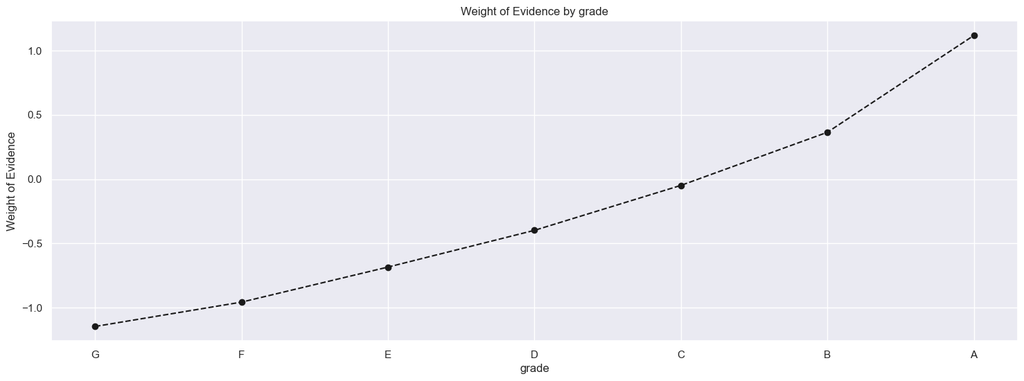

```python
plot_by_woe(df_temp)
```

We can see from the above graph that there is a continuous increase in WoE across the different grades. Therefore, we do not need to combine any features together and should leave all these 7 grades as they are

Note that there are no missing values in the grade column, otherwise we would have created a separate and independent category for all Missing values, that would never be combined with any other category. We will come across this scenario when working through other features.

```python
df_temp = woe_discrete(X_train_prepr, 'home_ownership', y_train_prepr)
df_temp
```

|  | home_ownership | n_obs | prop_good | prop_n_obs | n_good | n_bad | prop_n_good | prop_n_bad | WoE | diff_prop_good | diff_WoE | IV |
| --- | --- | --- | --- | --- | --- | --- | --- | --- | --- | --- | --- | --- |
| 0 | OTHER | 159 | 0.792453 | 0.000426 | 126.0 | 33.0 | 0.000379 | 0.000809 | -0.758081 | NaN | NaN | 0.02166 |
| 1 | NONE | 41 | 0.853659 | 0.000110 | 35.0 | 6.0 | 0.000105 | 0.000147 | -0.334267 | 0.061206 | 0.423814 | 0.02166 |
| 2 | RENT | 150776 | 0.874052 | 0.404195 | 131786.0 | 18990.0 | 0.396642 | 0.465738 | -0.160588 | 0.020393 | 0.173678 | 0.02166 |
| 3 | OWN | 33313 | 0.890343 | 0.089304 | 29660.0 | 3653.0 | 0.089269 | 0.089591 | -0.003605 | 0.016292 | 0.156984 | 0.02166 |
| 4 | MORTGAGE | 188739 | 0.904143 | 0.505965 | 170647.0 | 18092.0 | 0.513604 | 0.443714 | 0.146272 | 0.013800 | 0.149877 | 0.02166 |

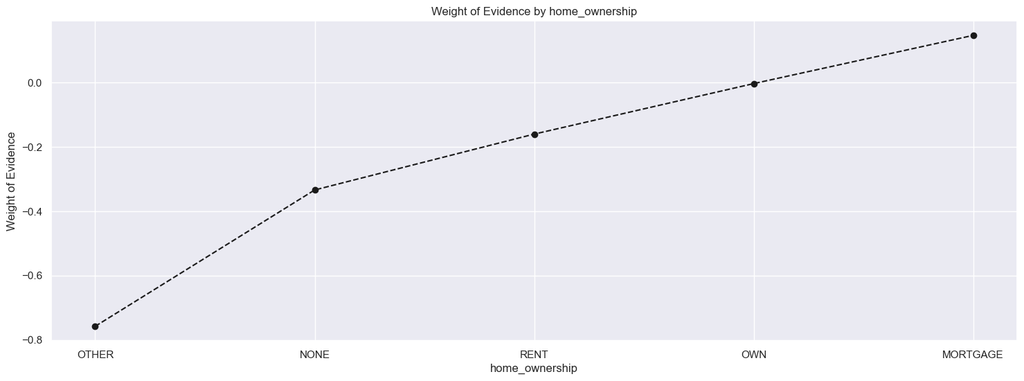

```python
plot_by_woe(df_temp)
```

```python
df_temp = woe_discrete(X_train_prepr, 'verification_status', y_train_prepr)
df_temp
```

|  | verification_status | n_obs | prop_good | prop_n_obs | n_good | n_bad | prop_n_good | prop_n_bad | WoE | diff_prop_good | diff_WoE | IV |
| --- | --- | --- | --- | --- | --- | --- | --- | --- | --- | --- | --- | --- |
| 0 | Verified | 134571 | 0.872045 | 0.360753 | 117352.0 | 17219.0 | 0.353200 | 0.422303 | -0.178691 | NaN | NaN | 0.022522 |
| 1 | Source Verified | 119969 | 0.895723 | 0.321609 | 107459.0 | 12510.0 | 0.323424 | 0.306813 | 0.052726 | 0.023678 | 0.231417 | 0.022522 |
| 2 | Not Verified | 118488 | 0.906784 | 0.317638 | 107443.0 | 11045.0 | 0.323376 | 0.270883 | 0.177128 | 0.011061 | 0.124402 | 0.022522 |

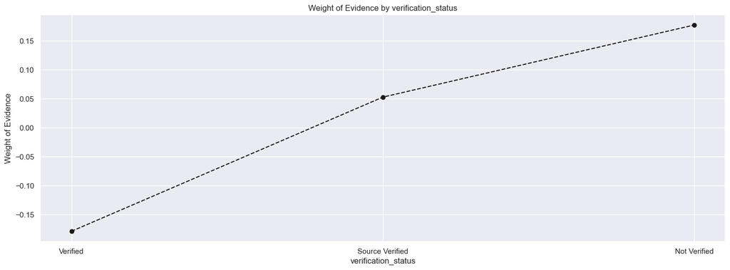

```python
plot_by_woe(df_temp)
```

```python
df_temp = woe_discrete(X_train_prepr, 'purpose', y_train_prepr)
df_temp
```

|  | purpose | n_obs | prop_good | prop_n_obs | n_good | n_bad | prop_n_good | prop_n_bad | WoE | diff_prop_good | diff_WoE | IV |
| --- | --- | --- | --- | --- | --- | --- | --- | --- | --- | --- | --- | --- |
| 0 | small_business | 5605 | 0.787333 | 0.015026 | 4413.0 | 1192.0 | 0.013282 | 0.029234 | -0.788933 | NaN | NaN | 0.036668 |
| 1 | educational | 351 | 0.792023 | 0.000941 | 278.0 | 73.0 | 0.000837 | 0.001790 | -0.760693 | 0.004690 | 0.028240 | 0.036668 |
| 2 | renewable_energy | 295 | 0.837288 | 0.000791 | 247.0 | 48.0 | 0.000743 | 0.001177 | -0.459668 | 0.045265 | 0.301026 | 0.036668 |
| 3 | moving | 2397 | 0.848561 | 0.006426 | 2034.0 | 363.0 | 0.006122 | 0.008903 | -0.374498 | 0.011273 | 0.085169 | 0.036668 |
| 4 | house | 1824 | 0.861294 | 0.004890 | 1571.0 | 253.0 | 0.004728 | 0.006205 | -0.271777 | 0.012733 | 0.102721 | 0.036668 |
| 5 | other | 19006 | 0.861675 | 0.050951 | 16377.0 | 2629.0 | 0.049291 | 0.064477 | -0.268581 | 0.000381 | 0.003196 | 0.036668 |
| 6 | medical | 3750 | 0.863467 | 0.010053 | 3238.0 | 512.0 | 0.009746 | 0.012557 | -0.253469 | 0.001791 | 0.015112 | 0.036668 |
| 7 | vacation | 2003 | 0.875686 | 0.005370 | 1754.0 | 249.0 | 0.005279 | 0.006107 | -0.145654 | 0.012220 | 0.107815 | 0.036668 |
| 8 | wedding | 1900 | 0.881053 | 0.005093 | 1674.0 | 226.0 | 0.005038 | 0.005543 | -0.095419 | 0.005366 | 0.050235 | 0.036668 |
| 9 | debt_consolidation | 219196 | 0.886704 | 0.587613 | 194362.0 | 24834.0 | 0.584980 | 0.609065 | -0.040346 | 0.005652 | 0.055072 | 0.036668 |
| 10 | home_improvement | 21253 | 0.901614 | 0.056974 | 19162.0 | 2091.0 | 0.057673 | 0.051283 | 0.117432 | 0.014910 | 0.157778 | 0.036668 |
| 11 | major_purchase | 7873 | 0.905246 | 0.021106 | 7127.0 | 746.0 | 0.021450 | 0.018296 | 0.159065 | 0.003632 | 0.041633 | 0.036668 |
| 12 | car | 4246 | 0.911211 | 0.011383 | 3869.0 | 377.0 | 0.011645 | 0.009246 | 0.230651 | 0.005965 | 0.071586 | 0.036668 |
| 13 | credit_card | 83329 | 0.913824 | 0.223385 | 76148.0 | 7181.0 | 0.229186 | 0.176117 | 0.263385 | 0.002613 | 0.032734 | 0.036668 |

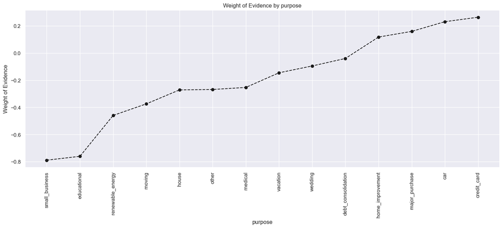

```python
plot_by_woe(df_temp, 90)
```

```python
# We define a function to calculate WoE of continuous variables. This is same as the function we defined earlier for discrete variables.
# The only difference are the 2 commented lines of code in the function that results in the df being sorted by continuous variable values
def woe_ordered_continuous(df, continuous_variabe_name, y_df):
    df = pd.concat([df[continuous_variabe_name], y_df], axis = 1)
    df = pd.concat([df.groupby(df.columns.values[0], as_index = False)[df.columns.values[1]].count(),
                    df.groupby(df.columns.values[0], as_index = False)[df.columns.values[1]].mean()], axis = 1)
    df = df.iloc[:, [0, 1, 3]]
    df.columns = [df.columns.values[0], 'n_obs', 'prop_good']
    df['prop_n_obs'] = df['n_obs'] / df['n_obs'].sum()
    df['n_good'] = df['prop_good'] * df['n_obs']
    df['n_bad'] = (1 - df['prop_good']) * df['n_obs']
    df['prop_n_good'] = df['n_good'] / df['n_good'].sum()
    df['prop_n_bad'] = df['n_bad'] / df['n_bad'].sum()
    df['WoE'] = np.log(df['prop_n_good'] / df['prop_n_bad'])
    #df = df.sort_values(['WoE'])
    #df = df.reset_index(drop = True)
    df['diff_prop_good'] = df['prop_good'].diff().abs()
    df['diff_WoE'] = df['WoE'].diff().abs()
    df['IV'] = (df['prop_n_good'] - df['prop_n_bad']) * df['WoE']
    df['IV'] = df['IV'].sum()
    return df
```

```python
df_temp = woe_ordered_continuous(X_train_prepr, 'term', y_train_prepr)
df_temp
```

|  | term | n_obs | prop_good | prop_n_obs | n_good | n_bad | prop_n_good | prop_n_bad | WoE | diff_prop_good | diff_WoE | IV |
| --- | --- | --- | --- | --- | --- | --- | --- | --- | --- | --- | --- | --- |
| 0 | 36 | 270199 | 0.903238 | 0.72434 | 244054.0 | 26145.0 | 0.73454 | 0.641217 | 0.135876 | NaN | NaN | 0.040794 |
| 1 | 60 | 102829 | 0.857735 | 0.27566 | 88200.0 | 14629.0 | 0.26546 | 0.358783 | -0.301254 | 0.045503 | 0.43713 | 0.040794 |

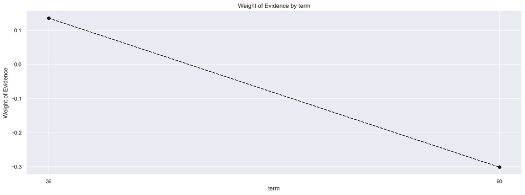

```python
plot_by_woe(df_temp)
```

```python
# fine-classing using the 'cut' method, given the large number of unique values
X_train_prepr['int_rate_factor'] = pd.cut(X_train_prepr['int_rate'], 50)
# Process 'int_rate_factor' column through woe_ordered_continuous and plot_by_woe functions
df_temp = woe_ordered_continuous(X_train_prepr, 'int_rate_factor', y_train_prepr)
df_temp
```

|  | int_rate_factor | n_obs | prop_good | prop_n_obs | n_good | n_bad | prop_n_good | prop_n_bad | WoE | diff_prop_good | diff_WoE | IV |
| --- | --- | --- | --- | --- | --- | --- | --- | --- | --- | --- | --- | --- |
| 0 | (5.399, 5.833] | 776 | 0.962629 | 0.002080 | 747.0 | 29.0 | 0.002248 | 0.000711 | 1.150914 | NaN | NaN | 0.346603 |
| 1 | (5.833, 6.246] | 8408 | 0.979305 | 0.022540 | 8234.0 | 174.0 | 0.024782 | 0.004267 | 1.759117 | 0.016677 | 0.608203 | 0.346603 |
| 2 | (6.246, 6.658] | 7842 | 0.971181 | 0.021023 | 7616.0 | 226.0 | 0.022922 | 0.005543 | 1.419616 | 0.008125 | 0.339500 | 0.346603 |
| 3 | (6.658, 7.071] | 1777 | 0.969612 | 0.004764 | 1723.0 | 54.0 | 0.005186 | 0.001324 | 1.364983 | 0.001569 | 0.054633 | 0.346603 |
| 4 | (7.071, 7.484] | 3186 | 0.976146 | 0.008541 | 3110.0 | 76.0 | 0.009360 | 0.001864 | 1.613790 | 0.006534 | 0.248806 | 0.346603 |
| 5 | (7.484, 7.897] | 12590 | 0.963781 | 0.033751 | 12134.0 | 456.0 | 0.036520 | 0.011184 | 1.183419 | 0.012365 | 0.430371 | 0.346603 |
| 6 | (7.897, 8.31] | 9680 | 0.949483 | 0.025950 | 9191.0 | 489.0 | 0.027663 | 0.011993 | 0.835762 | 0.014297 | 0.347656 | 0.346603 |
| 7 | (8.31, 8.722] | 6666 | 0.965047 | 0.017870 | 6433.0 | 233.0 | 0.019362 | 0.005714 | 1.220303 | 0.015563 | 0.384540 | 0.346603 |
| 8 | (8.722, 9.135] | 9578 | 0.938923 | 0.025676 | 8993.0 | 585.0 | 0.027067 | 0.014347 | 0.634735 | 0.026124 | 0.585568 | 0.346603 |
| 9 | (9.135, 9.548] | 6563 | 0.965565 | 0.017594 | 6337.0 | 226.0 | 0.019073 | 0.005543 | 1.235771 | 0.026642 | 0.601036 | 0.346603 |
| 10 | (9.548, 9.961] | 7597 | 0.932868 | 0.020366 | 7087.0 | 510.0 | 0.021330 | 0.012508 | 0.533752 | 0.032696 | 0.702019 | 0.346603 |
| 11 | (9.961, 10.374] | 10937 | 0.935448 | 0.029320 | 10231.0 | 706.0 | 0.030793 | 0.017315 | 0.575707 | 0.002580 | 0.041956 | 0.346603 |
| 12 | (10.374, 10.786] | 5777 | 0.915354 | 0.015487 | 5288.0 | 489.0 | 0.015916 | 0.011993 | 0.282978 | 0.020094 | 0.292729 | 0.346603 |
| 13 | (10.786, 11.199] | 17733 | 0.931427 | 0.047538 | 16517.0 | 1216.0 | 0.049712 | 0.029823 | 0.510968 | 0.016073 | 0.227990 | 0.346603 |
| 14 | (11.199, 11.612] | 4819 | 0.916165 | 0.012919 | 4415.0 | 404.0 | 0.013288 | 0.009908 | 0.293493 | 0.015262 | 0.217475 | 0.346603 |
| 15 | (11.612, 12.025] | 15494 | 0.932748 | 0.041536 | 14452.0 | 1042.0 | 0.043497 | 0.025556 | 0.531836 | 0.016583 | 0.238343 | 0.346603 |
| 16 | (12.025, 12.438] | 12356 | 0.896164 | 0.033124 | 11073.0 | 1283.0 | 0.033327 | 0.031466 | 0.057454 | 0.036584 | 0.474382 | 0.346603 |
| 17 | (12.438, 12.85] | 11008 | 0.921148 | 0.029510 | 10140.0 | 868.0 | 0.030519 | 0.021288 | 0.360196 | 0.024984 | 0.302743 | 0.346603 |
| 18 | (12.85, 13.263] | 21451 | 0.903268 | 0.057505 | 19376.0 | 2075.0 | 0.058317 | 0.050890 | 0.136219 | 0.017880 | 0.223978 | 0.346603 |
| 19 | (13.263, 13.676] | 15377 | 0.905768 | 0.041222 | 13928.0 | 1449.0 | 0.041920 | 0.035537 | 0.165172 | 0.002500 | 0.028954 | 0.346603 |
| 20 | (13.676, 14.089] | 10984 | 0.899126 | 0.029446 | 9876.0 | 1108.0 | 0.029724 | 0.027174 | 0.089696 | 0.006642 | 0.075477 | 0.346603 |
| 21 | (14.089, 14.502] | 23313 | 0.888388 | 0.062497 | 20711.0 | 2602.0 | 0.062335 | 0.063815 | -0.023471 | 0.010738 | 0.113166 | 0.346603 |
| 22 | (14.502, 14.914] | 4431 | 0.863688 | 0.011878 | 3827.0 | 604.0 | 0.011518 | 0.014813 | -0.251593 | 0.024701 | 0.228122 | 0.346603 |
| 23 | (14.914, 15.327] | 19020 | 0.880442 | 0.050988 | 16746.0 | 2274.0 | 0.050401 | 0.055771 | -0.101236 | 0.016754 | 0.150357 | 0.346603 |
| 24 | (15.327, 15.74] | 12381 | 0.887893 | 0.033191 | 10993.0 | 1388.0 | 0.033086 | 0.034041 | -0.028460 | 0.007451 | 0.072776 | 0.346603 |
| 25 | (15.74, 16.153] | 7475 | 0.837191 | 0.020039 | 6258.0 | 1217.0 | 0.018835 | 0.029847 | -0.460383 | 0.050702 | 0.431923 | 0.346603 |
| 26 | (16.153, 16.566] | 13068 | 0.859045 | 0.035032 | 11226.0 | 1842.0 | 0.033787 | 0.045176 | -0.290475 | 0.021854 | 0.169909 | 0.346603 |
| 27 | (16.566, 16.978] | 4257 | 0.844961 | 0.011412 | 3597.0 | 660.0 | 0.010826 | 0.016187 | -0.402240 | 0.014084 | 0.111765 | 0.346603 |
| 28 | (16.978, 17.391] | 11418 | 0.854703 | 0.030609 | 9759.0 | 1659.0 | 0.029372 | 0.040688 | -0.325880 | 0.009742 | 0.076359 | 0.346603 |
| 29 | (17.391, 17.804] | 12339 | 0.838723 | 0.033078 | 10349.0 | 1990.0 | 0.031148 | 0.048806 | -0.449100 | 0.015980 | 0.123220 | 0.346603 |
| 30 | (17.804, 18.217] | 1257 | 0.828162 | 0.003370 | 1041.0 | 216.0 | 0.003133 | 0.005297 | -0.525196 | 0.010560 | 0.076097 | 0.346603 |
| 31 | (18.217, 18.63] | 10959 | 0.832101 | 0.029378 | 9119.0 | 1840.0 | 0.027446 | 0.045127 | -0.497261 | 0.003939 | 0.027936 | 0.346603 |
| 32 | (18.63, 19.042] | 6930 | 0.817027 | 0.018578 | 5662.0 | 1268.0 | 0.017041 | 0.031098 | -0.601519 | 0.015074 | 0.104258 | 0.346603 |
| 33 | (19.042, 19.455] | 4470 | 0.797315 | 0.011983 | 3564.0 | 906.0 | 0.010727 | 0.022220 | -0.728256 | 0.019712 | 0.126737 | 0.346603 |
| 34 | (19.455, 19.868] | 6744 | 0.822657 | 0.018079 | 5548.0 | 1196.0 | 0.016698 | 0.029332 | -0.563400 | 0.025342 | 0.164855 | 0.346603 |
| 35 | (19.868, 20.281] | 4914 | 0.832316 | 0.013173 | 4090.0 | 824.0 | 0.012310 | 0.020209 | -0.495725 | 0.009659 | 0.067675 | 0.346603 |
| 36 | (20.281, 20.694] | 3236 | 0.803152 | 0.008675 | 2599.0 | 637.0 | 0.007822 | 0.015623 | -0.691743 | 0.029164 | 0.196017 | 0.346603 |
| 37 | (20.694, 21.106] | 3972 | 0.795065 | 0.010648 | 3158.0 | 814.0 | 0.009505 | 0.019964 | -0.742121 | 0.008087 | 0.050379 | 0.346603 |
| 38 | (21.106, 21.519] | 2763 | 0.775968 | 0.007407 | 2144.0 | 619.0 | 0.006453 | 0.015181 | -0.855532 | 0.019097 | 0.113411 | 0.346603 |
| 39 | (21.519, 21.932] | 969 | 0.763674 | 0.002598 | 740.0 | 229.0 | 0.002227 | 0.005616 | -0.924927 | 0.012294 | 0.069395 | 0.346603 |
| 40 | (21.932, 22.345] | 3444 | 0.793554 | 0.009233 | 2733.0 | 711.0 | 0.008226 | 0.017438 | -0.751372 | 0.029880 | 0.173555 | 0.346603 |
| 41 | (22.345, 22.758] | 2292 | 0.760035 | 0.006144 | 1742.0 | 550.0 | 0.005243 | 0.013489 | -0.944984 | 0.033519 | 0.193612 | 0.346603 |
| 42 | (22.758, 23.17] | 1490 | 0.765101 | 0.003994 | 1140.0 | 350.0 | 0.003431 | 0.008584 | -0.917005 | 0.005066 | 0.027980 | 0.346603 |
| 43 | (23.17, 23.583] | 2681 | 0.781425 | 0.007187 | 2095.0 | 586.0 | 0.006305 | 0.014372 | -0.823866 | 0.016324 | 0.093139 | 0.346603 |
| 44 | (23.583, 23.996] | 1595 | 0.727273 | 0.004276 | 1160.0 | 435.0 | 0.003491 | 0.010669 | -1.117026 | 0.054152 | 0.293160 | 0.346603 |
| 45 | (23.996, 24.409] | 1452 | 0.781680 | 0.003892 | 1135.0 | 317.0 | 0.003416 | 0.007775 | -0.822369 | 0.054408 | 0.294657 | 0.346603 |
| 46 | (24.409, 24.822] | 1660 | 0.760843 | 0.004450 | 1263.0 | 397.0 | 0.003801 | 0.009737 | -0.940546 | 0.020837 | 0.118177 | 0.346603 |
| 47 | (24.822, 25.234] | 1344 | 0.773810 | 0.003603 | 1040.0 | 304.0 | 0.003130 | 0.007456 | -0.867907 | 0.012966 | 0.072639 | 0.346603 |
| 48 | (25.234, 25.647] | 774 | 0.736434 | 0.002075 | 570.0 | 204.0 | 0.001716 | 0.005003 | -1.070339 | 0.037375 | 0.202432 | 0.346603 |
| 49 | (25.647, 26.06] | 1781 | 0.754632 | 0.004774 | 1344.0 | 437.0 | 0.004045 | 0.010718 | -0.974383 | 0.018198 | 0.095956 | 0.346603 |

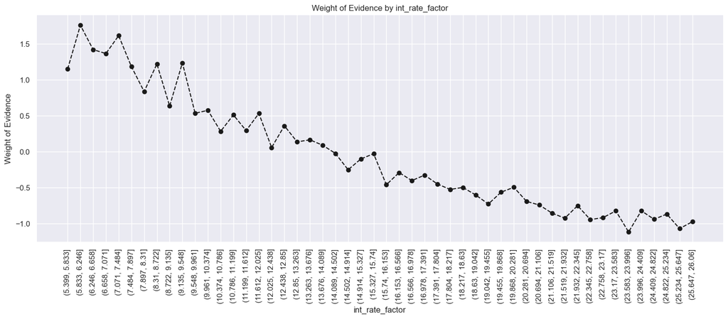

```python
plot_by_woe(df_temp, 90)
```

```python
df_temp = woe_ordered_continuous(X_train_prepr, 'emp_length', y_train_prepr)
df_temp
```

|  | emp_length | n_obs | prop_good | prop_n_obs | n_good | n_bad | prop_n_good | prop_n_bad | WoE | diff_prop_good | diff_WoE | IV |
| --- | --- | --- | --- | --- | --- | --- | --- | --- | --- | --- | --- | --- |
| 0 | 0 | 45764 | 0.876497 | 0.122682 | 40112.0 | 5652.0 | 0.120727 | 0.138618 | -0.138189 | NaN | NaN | 0.006408 |
| 1 | 1 | 23582 | 0.888262 | 0.063218 | 20947.0 | 2635.0 | 0.063045 | 0.064625 | -0.024743 | 0.011765 | 0.113446 | 0.006408 |
| 2 | 2 | 33123 | 0.889895 | 0.088795 | 29476.0 | 3647.0 | 0.088715 | 0.089444 | -0.008184 | 0.001633 | 0.016559 | 0.006408 |
| 3 | 3 | 29301 | 0.890925 | 0.078549 | 26105.0 | 3196.0 | 0.078569 | 0.078383 | 0.002372 | 0.001030 | 0.010555 | 0.006408 |
| 4 | 4 | 22482 | 0.891602 | 0.060269 | 20045.0 | 2437.0 | 0.060330 | 0.059768 | 0.009357 | 0.000677 | 0.006985 | 0.006408 |
| 5 | 5 | 24654 | 0.885374 | 0.066092 | 21828.0 | 2826.0 | 0.065697 | 0.069309 | -0.053524 | 0.006229 | 0.062881 | 0.006408 |
| 6 | 6 | 21057 | 0.883079 | 0.056449 | 18595.0 | 2462.0 | 0.055966 | 0.060382 | -0.075936 | 0.002294 | 0.022413 | 0.006408 |
| 7 | 7 | 20834 | 0.887204 | 0.055851 | 18484.0 | 2350.0 | 0.055632 | 0.057635 | -0.035365 | 0.004124 | 0.040571 | 0.006408 |
| 8 | 8 | 17859 | 0.889300 | 0.047876 | 15882.0 | 1977.0 | 0.047801 | 0.048487 | -0.014249 | 0.002096 | 0.021116 | 0.006408 |
| 9 | 9 | 14372 | 0.887142 | 0.038528 | 12750.0 | 1622.0 | 0.038374 | 0.039780 | -0.035984 | 0.002158 | 0.021735 | 0.006408 |
| 10 | 10 | 120000 | 0.900250 | 0.321692 | 108030.0 | 11970.0 | 0.325143 | 0.293569 | 0.102150 | 0.013108 | 0.138134 | 0.006408 |

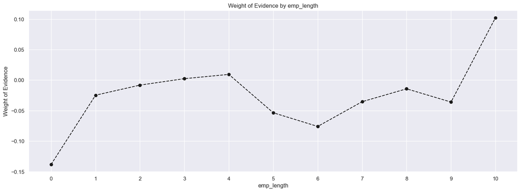

```python
plot_by_woe(df_temp)
```

We will not use this feature for the following reasons:

very low IV WoE ranges between a very small range, implying low power of differentiating between good and bad loans

```python
# fine-classing
X_train_prepr['annual_inc_factor'] = pd.cut(X_train_prepr['annual_inc'], 50)
# Process 'annual_inc_factor' column through woe_ordered_continuous and plot_by_woe functions
df_temp = woe_ordered_continuous(X_train_prepr, 'annual_inc_factor', y_train_prepr)
df_temp
```

|  | annual_inc_factor | n_obs | prop_good | prop_n_obs | n_good | n_bad | prop_n_good | prop_n_bad | WoE | diff_prop_good | diff_WoE | IV |
| --- | --- | --- | --- | --- | --- | --- | --- | --- | --- | --- | --- | --- |
| 0 | (-5602.104, 151858.08] | 356629 | 0.889078 | 0.956048 | 317071.0 | 39558.0 | 0.954315 | 0.970177 | -0.016485 | NaN | NaN | inf |
| 1 | (151858.08, 301820.16] | 14796 | 0.925047 | 0.039665 | 13687.0 | 1109.0 | 0.041195 | 0.027199 | 0.415145 | 0.035969 | 0.431630 | inf |
| 2 | (301820.16, 451782.24] | 1076 | 0.930297 | 0.002885 | 1001.0 | 75.0 | 0.003013 | 0.001839 | 0.493424 | 0.005250 | 0.078279 | inf |
| 3 | (451782.24, 601744.32] | 291 | 0.941581 | 0.000780 | 274.0 | 17.0 | 0.000825 | 0.000417 | 0.682072 | 0.011283 | 0.188648 | inf |
| 4 | (601744.32, 751706.4] | 96 | 0.906250 | 0.000257 | 87.0 | 9.0 | 0.000262 | 0.000221 | 0.170840 | 0.035331 | 0.511231 | inf |
| 5 | (751706.4, 901668.48] | 59 | 0.932203 | 0.000158 | 55.0 | 4.0 | 0.000166 | 0.000098 | 0.523196 | 0.025953 | 0.352355 | inf |
| 6 | (901668.48, 1051630.56] | 30 | 0.966667 | 0.000080 | 29.0 | 1.0 | 0.000087 | 0.000025 | 1.269453 | 0.034463 | 0.746257 | inf |
| 7 | (1051630.56, 1201592.64] | 19 | 1.000000 | 0.000051 | 19.0 | 0.0 | 0.000057 | 0.000000 | inf | 0.033333 | inf | inf |
| 8 | (1201592.64, 1351554.72] | 7 | 0.857143 | 0.000019 | 6.0 | 1.0 | 0.000018 | 0.000025 | -0.306084 | 0.142857 | inf | inf |
| 9 | (1351554.72, 1501516.8] | 5 | 1.000000 | 0.000013 | 5.0 | 0.0 | 0.000015 | 0.000000 | inf | 0.142857 | inf | inf |
| 10 | (1501516.8, 1651478.88] | 1 | 1.000000 | 0.000003 | 1.0 | 0.0 | 0.000003 | 0.000000 | inf | 0.000000 | NaN | inf |
| 11 | (1651478.88, 1801440.96] | 1 | 1.000000 | 0.000003 | 1.0 | 0.0 | 0.000003 | 0.000000 | inf | 0.000000 | NaN | inf |
| 12 | (1801440.96, 1951403.04] | 2 | 1.000000 | 0.000005 | 2.0 | 0.0 | 0.000006 | 0.000000 | inf | 0.000000 | NaN | inf |
| 13 | (1951403.04, 2101365.12] | 4 | 1.000000 | 0.000011 | 4.0 | 0.0 | 0.000012 | 0.000000 | inf | 0.000000 | NaN | inf |
| 14 | (3750948.0, 3900910.08] | 1 | 1.000000 | 0.000003 | 1.0 | 0.0 | 0.000003 | 0.000000 | inf | 0.000000 | NaN | inf |
| 15 | (4800682.56, 4950644.64] | 1 | 1.000000 | 0.000003 | 1.0 | 0.0 | 0.000003 | 0.000000 | inf | 0.000000 | NaN | inf |
| 16 | (4950644.64, 5100606.72] | 1 | 1.000000 | 0.000003 | 1.0 | 0.0 | 0.000003 | 0.000000 | inf | 0.000000 | NaN | inf |
| 17 | (5850417.12, 6000379.2] | 1 | 1.000000 | 0.000003 | 1.0 | 0.0 | 0.000003 | 0.000000 | inf | 0.000000 | NaN | inf |
| 18 | (6000379.2, 6150341.28] | 1 | 1.000000 | 0.000003 | 1.0 | 0.0 | 0.000003 | 0.000000 | inf | 0.000000 | NaN | inf |
| 19 | (7050113.76, 7200075.84] | 1 | 1.000000 | 0.000003 | 1.0 | 0.0 | 0.000003 | 0.000000 | inf | 0.000000 | NaN | inf |
| 20 | (7350037.92, 7500000.0] | 2 | 1.000000 | 0.000005 | 2.0 | 0.0 | 0.000006 | 0.000000 | inf | 0.000000 | NaN | inf |